# Compound half-life analysis

### Goal and Approach

We want to determine the elimination half-lives of the molecules in `pk_data.csv`. First, I will get a sense of what the data looks like and produce a series of exploratory plots. Then, I will do some non-linear modeling to determine the elimination half-lives of the compounds.

### Final thoughts

After this exercise, here are my final thoughts:

- The following modeling approach assumes that a 2 phase degradation curve can be fit to the data.
- This comes from the exploratory analysis which seems to suggest that most of the molecules are distributed at the same rate and then have a secondary decay rate corresponding to the elimination.
- In the end, I would only exclude from the data curves which I labeled as having “singular-convergence”.
- For the curves with convergence and the curves with no-convergence, I am fairly confident in the estimates.
- If I had more time, a major implementation I would do is to share estimates of the “distribution” half-life between molecules using a hierarchical modeling approach like Bayesian inference.
- I would also add more curve quality control and likely try to flag curves based off of CV.
- Finally, I would likely dig into the PK model a bit more to allow more nuance in how we model the elimination rate vs the distribution rate, with the assumption that elimination may not start right away.

### Setup

```r
library(ggplot2)
library(tidyverse)
data <- read.csv("pk_data.csv") |>
  mutate(
    is_control = is_control == "True"
  )
```

### Exploratory Analysis

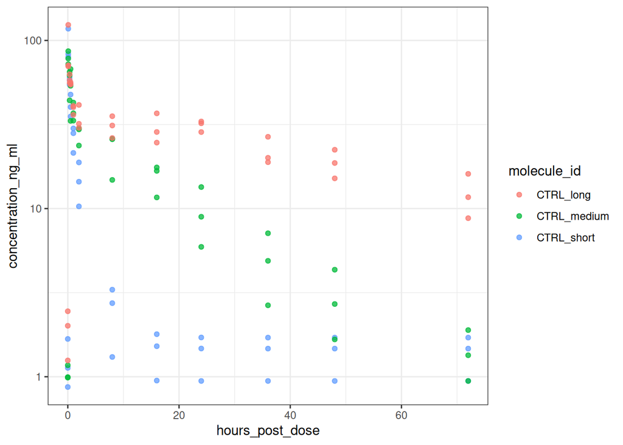

```r
data |>
  mutate(
    hours_post_dose = if_else(
      is.na(hours_post_dose),
      0, hours_post_dose
    )
  ) |>
  filter(
    is_control
  ) |>
  ggplot() +
    geom_point(
      aes(
        x = hours_post_dose,
        y = concentration_ng_ml,
        colour = molecule_id
      ),
      alpha = .75
    ) +
    scale_y_continuous(transform = "log10") +
    theme_bw()
```

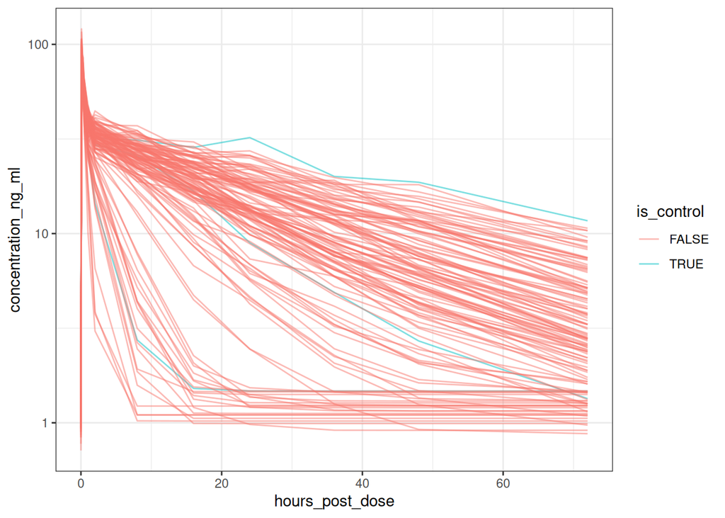

```r
data |>
  mutate(
    hours_post_dose = if_else(
      is.na(hours_post_dose),
      0, hours_post_dose
    )
  ) |>
  group_by(molecule_id, hours_post_dose, is_control) |>
  summarise(
    concentration_ng_ml = median(concentration_ng_ml),
    .groups = "drop"
  ) |>
  ggplot() +
    geom_line(
      aes(
        x = hours_post_dose,
        y = concentration_ng_ml,
        group = molecule_id,
        color = is_control
      ),
      alpha = .5
    ) +
    scale_y_continuous(transform = "log10") +
    theme_bw()
```

Some things I notice here. One of which is that, after their initial spike, some compounds have a second small spike which may mess up non-linear modeling. Furthermore, most compounds do not fully eliminate within the experiment, including the fast eliminating compounds. For this latter group, the effect is likely technical, but it is still good to note since it will need to be taken into account when we do calculations.

Lets look at a distribution of when the median of each time point falls bellow 50% of the 1hr concentration, which is a crude order of half-life

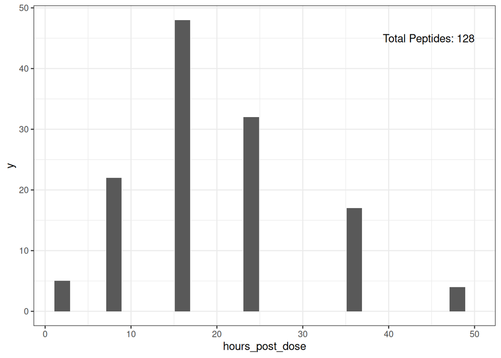

```r
threshold_point <- data |>
  filter(
    !is.na(hours_post_dose) & hours_post_dose >= 1
  ) |>
  group_by(
    molecule_id, hours_post_dose, is_control
  ) |>
  summarise(
    concentration_ng_ml = median(concentration_ng_ml),
    .groups = "drop"
  ) |>
  group_by(molecule_id) |>
  mutate(
    passed_threshold = concentration_ng_ml < .5 * first(concentration_ng_ml)
  ) |>
  ungroup() |>
  filter(passed_threshold) |>
  distinct(molecule_id, .keep_all = T)

threshold_point|>
  ggplot() +
    geom_bar(
      aes(
        x = hours_post_dose
      )
    ) +
    geom_text(
      aes(
        x = 50,
        y = 45,
        label = paste("Total Peptides:", dim(threshold_point)[1])
      ),
      hjust = 1,
      data = data.frame()
    ) +
    theme_bw()
```

### Defining a curve fitting procedure on controls

The file `utils/fit_two_phase_decay.R` contains a NLS fitting function generated by Claude for fitting the decay curves that we have here. The function gives me several different controls: - For curves where I know nothing, all parameters are fit. - When I know the baseline value, e.g. from “pre-bleed”, then I can specify this baseline - When I know one half-life, I can specify this so the other half-life is fit instead.

In the following I will validate this function using the controls.

```r
source("utils/fit_two_phase_decay.R")
```

```r
fit_list <- data |>
  filter(
    str_starts(molecule_id, "CTRL")
  ) |>
  group_by(
    molecule_id
  ) |>
  group_map(
    function(df, key) {
      baseline = df %>%
        filter(
          timepoint_label == "pre-bleed"
        ) |>
        summarise(
          concentration_ng_ml = median(concentration_ng_ml)
        ) |>
        unlist()

      df_filtered <- df %>%
        filter(
          timepoint_label != "pre-bleed"
        )

      fit <- fit_two_phase_decay(
        x = df_filtered$hours_post_dose,
        y = df_filtered$concentration_ng_ml,
        baseline = baseline
      )
      fit[["molecule_id"]] = unlist(key)

      return(fit)
    }
  )
```

```r
lapply(fit_list, function(entry) entry[c("molecule_id", "halflife1", "halflife2", "r_squared")]) %>%
  bind_rows()
```

```
## # A tibble: 3 × 4
##   molecule_id halflife1 halflife2 r_squared
##   <chr>           <dbl>     <dbl>     <dbl>
## 1 CTRL_long       0.246     48.0      0.856
## 2 CTRL_medium     0.328     13.4      0.942
## 3 CTRL_short      0.206      1.54     0.963
```

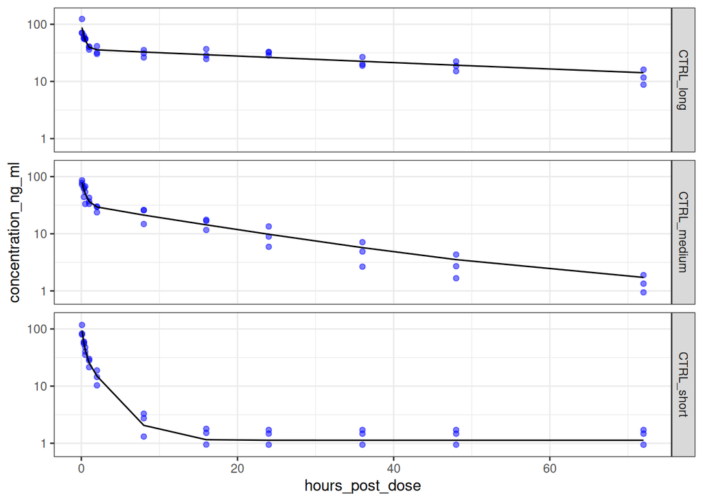

```r
lapply(fit_list, function(entry) {
  data_filtered <- data |>
    filter(
      molecule_id == entry["molecule_id"],
      timepoint_label != "pre-bleed"
    )

  data_filtered[["concentration_ng_ml_pred"]] <-
    predict_two_phase_decay(entry, data_filtered$hours_post_dose)

  return(data_filtered)
  }
) %>%
  bind_rows() %>%
  ggplot() +
    geom_point(
      aes(
        x = hours_post_dose,
        y = concentration_ng_ml
      ),
      color = "blue",
      alpha = .5
    ) +
    geom_line(
      aes(
        x = hours_post_dose,
        y = concentration_ng_ml_pred
      )
    ) +
    scale_y_continuous(transform = "log10", limits = c(0.75, 150)) +
    theme_bw() +
    facet_grid(molecule_id ~ .)
```

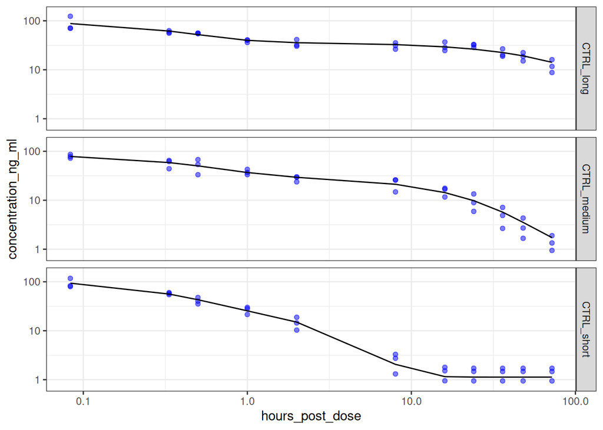

```r
lapply(fit_list, function(entry) {
  data_filtered <- data |>
    filter(
      molecule_id == entry["molecule_id"],
      timepoint_label != "pre-bleed"
    )

  data_filtered[["concentration_ng_ml_pred"]] <-
    predict_two_phase_decay(entry, data_filtered$hours_post_dose)

  return(data_filtered)
  }
) %>%
  bind_rows() %>%
  ggplot() +
    geom_point(
      aes(
        x = hours_post_dose,
        y = concentration_ng_ml
      ),
      color = "blue",
      alpha = .5
    ) +
    geom_line(
      aes(
        x = hours_post_dose,
        y = concentration_ng_ml_pred
      )
    ) +
    scale_x_continuous(transform = "log10") +
    scale_y_continuous(transform = "log10", limits = c(0.75, 150)) +
    theme_bw() +
    facet_grid(molecule_id ~ .)
```

### Fit to entire dataset

First, I will do a very liberal fit with all of the peptide to get a sense of distribution and elimination

```r
fit_list <- data |>
  group_by(
    molecule_id
  ) |>
  group_map(
    function(df, key) {
      baseline = df |>
        filter(
          timepoint_label == "pre-bleed"
        ) |>
        summarise(
          concentration_ng_ml = median(concentration_ng_ml)
        ) |>
        unlist()

      df_filtered <- df |>
        filter(
          timepoint_label != "pre-bleed"
        )


      fit <- tryCatch(
        fit <- fit_two_phase_decay(
          x = df_filtered$hours_post_dose,
          y = df_filtered$concentration_ng_ml,
          baseline = baseline,
          control = nls.control(maxiter = 1000, warnOnly = T)
        ),
        error = function(e) list()
      )
      fit[["message"]] <- fit$model$message
      fit[["molecule_id"]] <- unlist(key)

      return(fit)
    }
  )
```

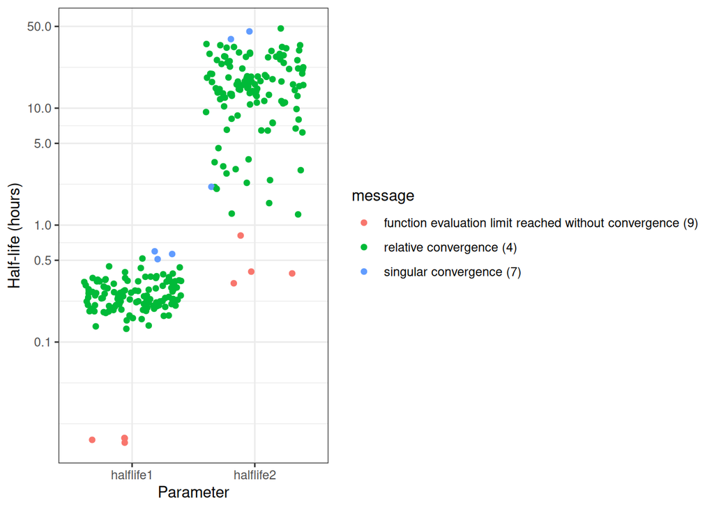

```r
lapply(fit_list, function(entry) entry[c("molecule_id", "message", "halflife1", "halflife2")]) |>
  bind_rows() |>
  pivot_longer(
    3:4,
    names_to = "Parameter"
  ) |>
  ggplot() +
    geom_jitter(
      aes(
        x = Parameter,
        y = value,
        color = message
      )
    ) +
    scale_y_continuous(
      "Half-life (hours)",
      transform = "log10",
      breaks = c(0.1, 0.5, 1, 5, 10, 50)
    ) +
    theme_bw()
```

Overall, this is really good. The distribution half-life is very consistent and below 30 minutes whereas the actual half-lives vary from 1 to about 50 hours. There are some convergence failures. Some of these appear to be extremely fast degradation where the model cannot parse out the true elimination half-life vs very slow degradation curves.

At this point, I am going to output a ranked list of curves since I believe that most are pretty good, but I will flag the ones with less confidence.

```r
lapply(fit_list, function(entry) entry[c("molecule_id", "baseline", "halflife1", "halflife2", "r_squared", "message")]) |>
  bind_rows() |>
  rename(
    distribution_half_life = halflife1,
    elimination_half_life = halflife2
  ) |>
  mutate(
    message = recode_values(
      message,
      "relative convergence (4)" ~ "converged",
      "singular convergence (7)" ~ "singular-convergence",
      "function evaluation limit reached without convergence (9)" ~ "no-convergence"
    )
  ) |>
  arrange(
    elimination_half_life
  ) |>
  write_csv(
    "molecule_half_lives.csv"
  )
```

### Evaluating failures

Lets look at one of the fast and and one of the slow curves to see what is up of those non-converging curves and see if something can be done.

The following curve for peptide LIB027 did not converge and appeared as though it had a fast half-life.

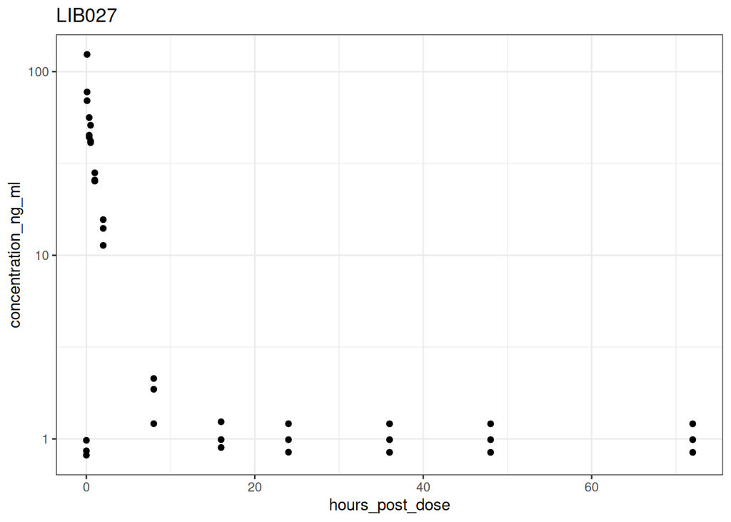

```r
data |>
  filter(
    molecule_id == "LIB027"
  ) %>%
  mutate(
    hours_post_dose = if_else(
      is.na(hours_post_dose),
      0, hours_post_dose
    )
  ) %>%
  ggplot() +
    geom_point(
      aes(
        x = hours_post_dose,
        y = concentration_ng_ml
      )
    ) +
    scale_y_continuous(transform = "log10") +
    theme_bw() +
    ggtitle(
      "LIB027"
    )
```

This appears to be correct and so the assumption that the model can’t estimate distribution here is likely true.

The following curve for peptide LIB076 did not converge and appeared as though it had a slow half-life.

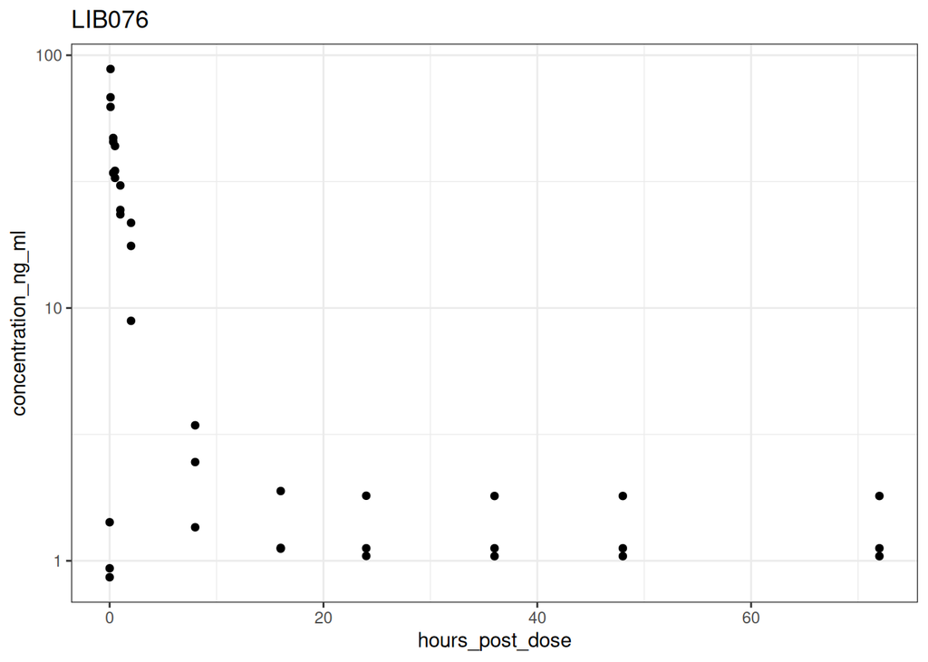

```r
data |>
  filter(
    molecule_id == "LIB076"
  ) %>%
  mutate(
    hours_post_dose = if_else(
      is.na(hours_post_dose),
      0, hours_post_dose
    )
  ) %>%
  ggplot() +
    geom_point(
      aes(
        x = hours_post_dose,
        y = concentration_ng_ml
      )
    ) +
    scale_y_continuous(transform = "log10") +
    theme_bw() +
    ggtitle(
      "LIB076"
    )
```

This does not look slow so somthing else must be killing the model’s ability to converge.